# Fine particulate matter (PM2.5) Visualization

Charin Polpanumas

February 3, 2559 BE

# Executive Summary

This report visualizes fine particulate matter (PM2.5) emission in the United States over the 10-year period 1999 to 2008, based on the [National Emissions Inventory (NEI) dataset](http://www.epa.gov/air-emissions-inventories/national-emissions-inventory) by the [Environmental Protection Agency (EPA)](http://www3.epa.gov). For each year and for each type of PM source, the NEI records how many tons of PM2.5 were emitted from that source over the course of the entire year. The time periods are 1999, 2002, 2005, and 2008.

# Data Processing

We download, unzip and read the files to `NEI` (summary) and `SCC` (source classification) data frames.

```r
#Download then unzip
if(!file.exists('fnei.zip')){
    download.file(url='https://d396qusza40orc.cloudfront.net/exdata%2Fdata%2FNEI_data.zip',destfile='fnei.zip')
    unzip('fnei.zip')
}

#Read
NEI <- readRDS("summarySCC_PM25.rds")
SCC <- readRDS("Source_Classification_Code.rds")
```

# Exploratory Data Analysis

The first two plots use the base plot package while the rest use `ggplot2`. ## Total emission in US We aggregate the emission amount by year then plot the total emission from all sources in the United States from 1999-2008.

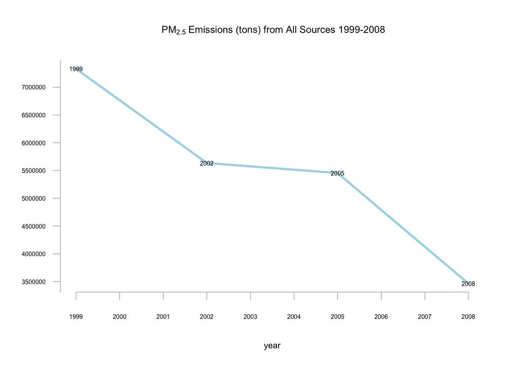

```r
#Aggregate and name columns
yearem <-aggregate(NEI$Emissions,by=list(NEI$year),sum)
names(yearem)<-c('year','Emissions')

#Plot
plot(yearem$year,yearem$Emissions,type='l', xlab='year',
     ylab='', main=~ PM[2.5] ~'Emissions (tons) from All Sources 1999-2008',
     lwd=3, col='lightblue', axes=FALSE,cex.lab=0.7, cex.main=0.8)

#Annotate
text(yearem$year,yearem$Emissions,yearem$year,cex=0.5)

#Axis
axis(1, at = seq(1999, 2008, by = 1), las=1, cex.axis=0.5, col='grey')
axis(2, at = seq(3000000,7500000,by=500000), las=1, cex.axis=0.5, col='grey')
```

## Total emission in Baltimore City We aggregate the emission amount by year and the condition that the city is Baltimore City `fips=='24510'` then plot the emissions for the city from 1999-2008.

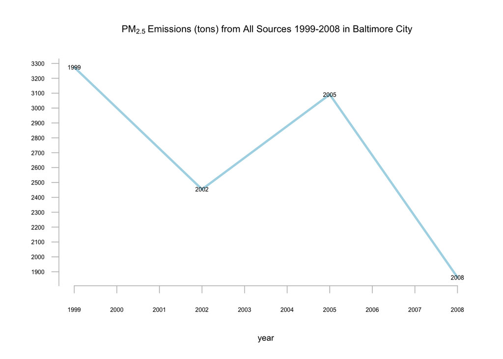

```r
#Aggregate and name columns
balem <-aggregate(NEI$Emissions,by=list(NEI$year, NEI$fips=='24510'),sum)
names(balem) <-c('year','Bal','Emissions')
balem<-balem[balem$Bal==TRUE,]

#Plot
plot(balem$year,balem$Emissions,type='l', xlab='year',
     ylab='', main=~ PM[2.5] ~'Emissions (tons) from All Sources 1999-2008 in Baltimore City',
     lwd=3, col='lightblue', axes=FALSE,cex.lab=0.7, cex.main=0.8)

#Annotate
text(balem$year,balem$Emissions,balem$year,cex=0.5)

#Axis
axis(1, at = seq(1999, 2008, by = 1), las=1, cex.axis=0.5, col='grey')
axis(2, at = seq(1500,3500,by=100), las=1, cex.axis=0.5, col='grey')
```

## Emission by sources in Baltimore City We aggregate the emission amount by year, source of emission and the condition that the city is Baltimore City `fips=='24510'` then plot the emissions for the city from 1999-2008.

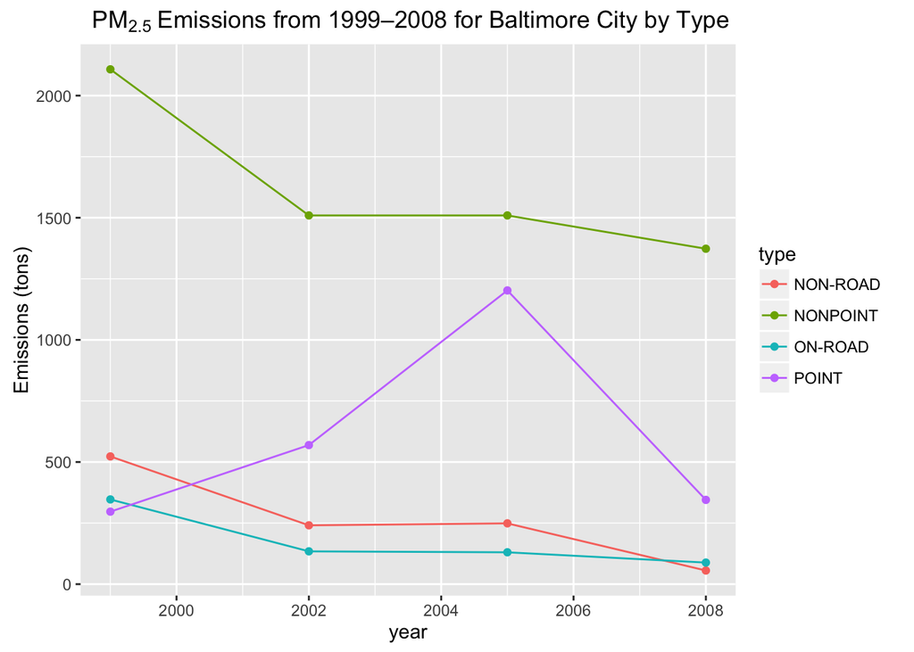

```r
#Aggregate and name columns
balem <-aggregate(NEI$Emissions,by=list(NEI$year, NEI$fips=='24510',NEI$type),sum)
names(balem) <-c('year','Bal','type','Emissions')
balem<-balem[balem$Bal==TRUE,]

#Plot
library(ggplot2)
qplot(year,Emissions,data=balem, geom=c('line','point'), color=type,
      main=~ PM[2.5] ~'Emissions from 1999–2008 for Baltimore City by Type', ylab='Emissions (tons)')
```

## Emission by coal-combusted sources We filter for `Coal` in the `SCC` dataset to get coal-related combustions. With this `index`, we aggregate the emission by year for the coal-combusted sources then plot the emissions from 1999-2008.

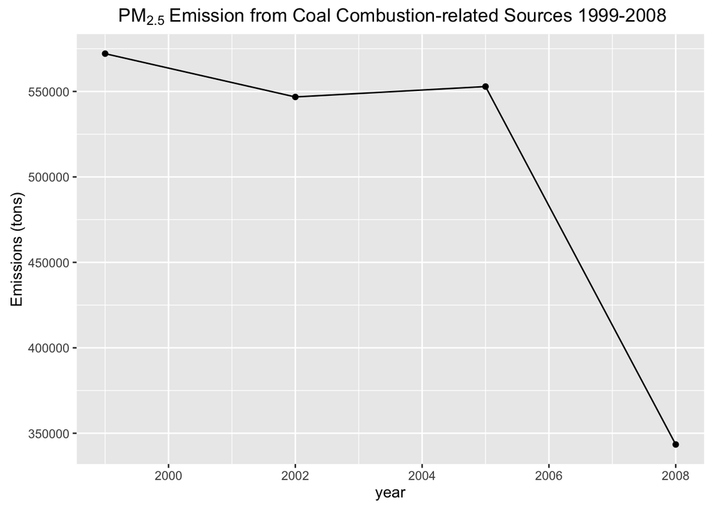

```r
#Get SCC for coal-related combustions
i<-grep('Coal',SCC$EI.Sector,ignore.case = TRUE)
index <-SCC[i,]$SCC

#Aggregate and name columns
coalem <-aggregate(NEI$Emissions,by=list(NEI$year, NEI$SCC %in% index),sum)
names(coalem) <-c('year','Coal','Emissions')
coalem<-coalem[coalem$Coal==TRUE,]

#Plot
library(ggplot2)
qplot(year,Emissions,data=coalem, geom=c('line','point'),
      main=~ PM[2.5] ~'Emission from Coal Combustion-related Sources 1999-2008', ylab='Emissions (tons)')
```

## Emission from motor sources in Baltimore City We aggregate the emission amount by year, the condition that the city is Baltimore City `fips=='24510'`, and that the emission comes from a motor souce `NEI$type=='ON-ROAD'` then plot the emissions for the city from 1999-2008.

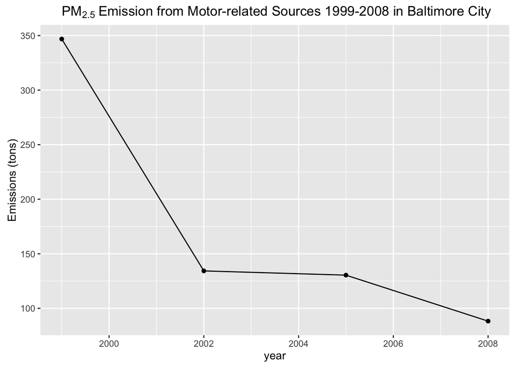

```r
motorem <-aggregate(NEI$Emissions,
                    by=list(NEI$year, NEI$fips=='24510', NEI$type=='ON-ROAD'),sum)
names(motorem) <-c('year','type','Bal','Emissions')
motorem<-motorem[motorem$type==TRUE & motorem$Bal==TRUE,]

#Plot
library(ggplot2)
qplot(year,Emissions,data=motorem, geom=c('line','point'),
      main=~ PM[2.5] ~'Emission from Motor-related Sources 1999-2008 in Baltimore City',
      ylab='Emissions (tons)')
```

## Comparison of changes in emission between Baltimore City and LA County We aggregate the emission amount by year, city, and the condition that the emission comes from a motor souce `NEI$type=='ON-ROAD'`. We filter the dataset so that the data comes from Baltimore City (`fips=='24510'`) and LA County (`fips=='06037'`) then plot the emissions for the city from 1999-2008.

```r
motorem <-aggregate(NEI$Emissions,
                    by=list(NEI$year, NEI$type=='ON-ROAD',NEI$fips),sum)
names(motorem) <-c('year','type','fips','Emissions')
motorem<-motorem[motorem$type==TRUE &
                       (motorem$fips=='24510'|motorem$fips=='06037'),]
motorem$city <-ifelse(motorem$fips=='24510','Baltimore City','LA County')
```

Since we are interested in how emission changes in both cities, we choose emission level in 1999 as the base line for both cities and set the emission equal to 1. Then we plot the changes from 1999 to 2008.

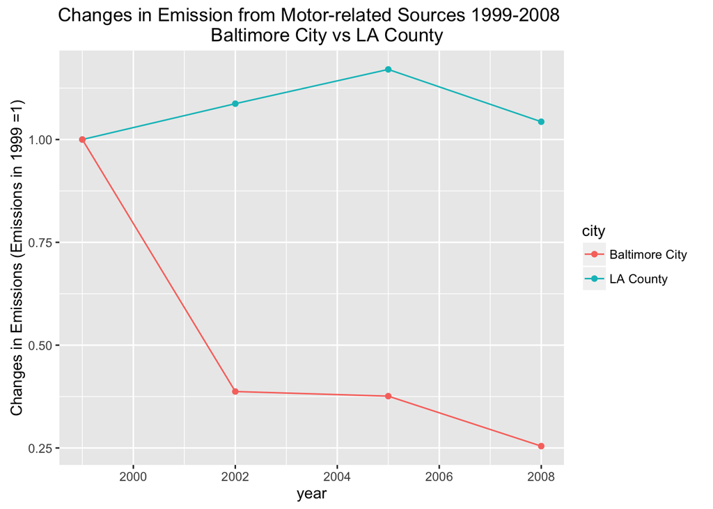

```r
#Create changes variable with the baseline being Emissions in 1999 for both cities
baseline<-motorem[motorem$year==1999,]
motorem$baseline<-ifelse(motorem$fips=='24510',baseline[baseline$fips=='24510',4],
                         baseline[baseline$fips=='06037',4])
motorem$changes<-motorem$Emissions/motorem$baseline

#Plot
library(ggplot2)
qplot(year,changes,data=motorem, geom=c('line','point'),
      main='Changes in Emission from Motor-related Sources 1999-2008
      Baltimore City vs LA County',
      color=city, ylab='Changes in Emissions (Emissions in 1999 =1)')
```